# Concentración de medicamentos

CONTENIDO

- Implementación
  - Datos
  - Análisis exploratorio
- ANCOVA
  - Modelo de RLM
  - Ajuste del modelo
  - Reducción del modelo
  - Modelo reducido
- Verificación de supuestos
  - Linealidad
  - Normalidad
  - Homocedasticidad

## Implementación

### Datos

**Variables**

- $y_i := \text{ Medida de eficacia de la vacuna } i$
- $x_{i,1} := \text{ Concentración del medicamento } i$
- $x_{i,j} =\begin{cases} 1, & \text{ si al individuo } i \text{ se le aplicó } j, j=\left \{ A,B,C\right \} \\ 0 & \text{ e.o.c } . \end{cases}$

### Análisis exploratorio

Procedamos a ver que sucede con los datos.

| X | y count | y mean | y std | y min | y 25% | y 50% | y 75% | y max |
| --- | --- | --- | --- | --- | --- | --- | --- | --- |
| A | 100.0 | 14.757940 | 3.295384 | 9.006294 | 12.392372 | 14.584917 | 16.582950 | 23.549324 |
| B | 100.0 | 15.132687 | 3.273415 | 7.345269 | 12.781925 | 14.379810 | 17.016111 | 26.558752 |
| C | 100.0 | 15.167974 | 3.542746 | 9.168442 | 13.001388 | 14.265555 | 16.410518 | 28.454093 |

| X | y |
| --- | --- |
| A | 10.859553 |
| B | 10.715248 |
| C | 12.551048 |

Muestralmente observamos lo siguiente:

- El número de observaciones es el mismo $(n = 100)$ para cada aplicación.
- En promedio la medida para la aplicación $A$ es de 14.76; la de la aplicación $B$ es de 15.13; por último, la de la aplicación $C$ es de 15.17.
- Notamos mayor variabilidad para la aplicación $C$ y menor variabilidad en los datos de $A$ y $B$.

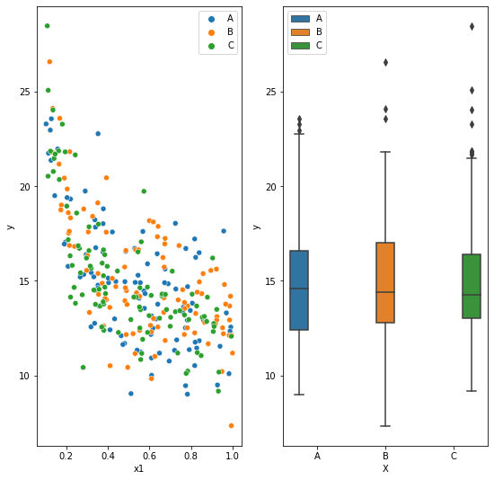

Las gráficas anteriores sugieren que la concentración del medicamento influye en la efectividad de cada aplicación (se nota una pendiente $\neq$ 0 en cada uno de los grupos).

## ANCOVA

### Modelo de RLM

El modelo de *RLM* con interacciones esta parametrizado de la siguiente manera

$y_i = \beta_0 + \underbrace{\beta_1 x_{i,1}}_{Variable 1} + \underbrace{\beta_2 x_{i,B} + \beta_3 x_{i,C}}_{Medicamentos} + \underbrace{\beta_4 x_{i,B}x_{i,1} + \beta_5 x_{i,C}x_{i,1}}_{\text{Medicamento con concentración}} + \epsilon_i$

donde $\epsilon_i \text{N}\left ( 0, \sigma^2 \right ), \forall i\in \left \{ 1 , \dots , n \right \}. $

Observación: En la parametrización del modelo se consideró la aplicación $A$ como el nivel de referencia, entonces

- Si al individuo $i$ se aplica $A$, entonces $x_{i,B}=x_{i,C}=0$

$$ \hat{\mathbb{E}}\left [ y_i; X A , x_i \right ] = \hat{ \beta}_0 + \hat{\beta}_1x_{i,1} $$

- Si al individuo $i$ se aplica $B$, entonces $x_{i,B}=1$ y $x_{i,C}= 0$

$$ \hat{\mathbb{E}}\left [ y_i; XB , x_i \right ] = \left ( \hat{ \beta}_0 + \hat{\beta}_2 \right ) + \left ( \hat{ \beta}_1 + \hat{\beta}_4 \right )x_{i,1} $$

- Si al individuo $i$ se aplica $C$, entonces $x_{i,C}=1$ y $x_{i,B}= 0$

### Ajuste del modelo

```
                            OLS Regression Results
==============================================================================
Dep. Variable:                      y   R-squared:                       0.435
Model:                            OLS   Adj. R-squared:                  0.425
Method:                 Least Squares   F-statistic:                     45.21
Date:                Mon, 26 Sep 2022   Prob (F-statistic):           1.52e-34
Time:                        16:29:19   Log-Likelihood:                -703.79
No. Observations:                 300   AIC:                             1420.
Df Residuals:                     294   BIC:                             1442.
Df Model:                           5
Covariance Type:            nonrobust
==============================================================================
                 coef    std err          t      P>|t|      [0.025      0.975]
------------------------------------------------------------------------------
Intercept     19.5575      0.645     30.323      0.000      18.288      20.827
x1            -8.7096      1.075     -8.103      0.000     -10.825      -6.594
xB             0.2315      0.892      0.260      0.795      -1.524       1.987
xC             0.3986      0.858      0.465      0.643      -1.290       2.087
x1:xB          0.6280      1.450      0.433      0.665      -2.226       3.482
x1:xC         -0.9879      1.484     -0.666      0.506      -3.908       1.932
==============================================================================
Omnibus:                        7.845   Durbin-Watson:                   1.863
Prob(Omnibus):                  0.020   Jarque-Bera (JB):                7.761
Skew:                           0.347   Prob(JB):                       0.0206
Kurtosis:                       3.375   Cond. No.                         20.3
==============================================================================

Notes:
[1] Standard Errors assume that the covariance matrix of the errors is correctly specified.
```

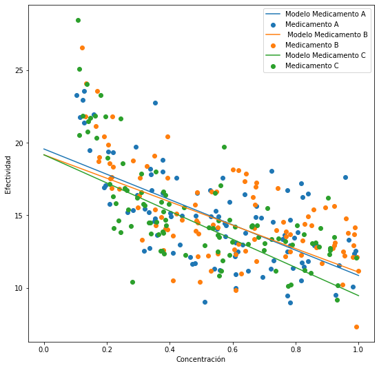

Las siguientes pruebas nos ayudarán a comprobar si esta aparente mejora observada para el medicamento \(B\) es significativa, pues la tendencia de los otros medicamentos es: *a mayor concentración, menor eficiencia*

### Reducción del modelo

Para poder reducir el modelo, es necesario verificar

1. ¿El modelo tiene sentido? (interpretar la prueba asociada a la tabla ANOVA). Se plantea la prueba de hipótesis:

$H_0: \beta_1 = \beta_2 = \cdots = \beta_{5} = 0 \text{ v.s. } H_a = \beta_i \neq 0, \text{ para alguna } i = 1, \dots , 5$

Tiene sentido pues el *p-value* de la prueba asociada a la tabla ANOVA es de: 1.5245453191242175e-34

Por lo tanto, rechazamos la hipotesis nula. Concluimos que: Con una confianza del 95% la concentración del medicamento o la simple aplicación de alguno de los medicamentos (A, B, C) nos ayudan a modelar el valor promedio de la efectividad de la vacuna.

1. ¿El efecto de la concentración es el mismo para los 3 medicamentos? (rectas con la misma pendiente). Se plantea la prueba de hipótesis:

$H_0: \beta_4= 0\text{ y } \beta_5=0 \text{ v.s. }H_a: \beta_4 \neq 0 \text{ o } \beta_5\neq 0 $.

Matricialmente (prueba lineal general):

$$H_0: \begin{pmatrix} 0&0&0&0&1&0\\ 0&0&0&0&0&1 \end{pmatrix}\begin{pmatrix} \beta_0 \\ \beta_1 \\ \beta_2 \\ \beta_3 \\ \beta_4\\ \beta_5 \end{pmatrix} = \begin{pmatrix} 0\\ 0 \end{pmatrix} \text{ v.s. } H_a:\begin{pmatrix} \beta_4 \\ \beta_5 \end{pmatrix} \neq \begin{pmatrix} 0\\ 0 \end{pmatrix}$$

Para esté apartado lo pasaremos a su lenguaje matricial con lo que obtenemos un *p-value* de: 0.5171

Por lo tanto no encontramos evidencia estadística suficiente para rechazar la hipótesis nula y concluimos que con una confianza del 95%

1. $\beta_4 =0 \text{ y } \beta_5 = 0$
2. El efecto de la concentración no es distinto en promedio para cada medicamento.
3. Todas las pendientes en las interacciones son similares en promedio.

### Modelo reducido

```
                            OLS Regression Results
==============================================================================
Dep. Variable:                      y   R-squared:                       0.432
Model:                            OLS   Adj. R-squared:                  0.426
Method:                 Least Squares   F-statistic:                     75.08
Date:                Mon, 26 Sep 2022   Prob (F-statistic):           3.86e-36
Time:                        16:29:20   Log-Likelihood:                -704.47
No. Observations:                 300   AIC:                             1417.
Df Residuals:                     296   BIC:                             1432.
Df Model:                           3
Covariance Type:            nonrobust
==============================================================================
                 coef    std err          t      P>|t|      [0.025      0.975]
------------------------------------------------------------------------------
Intercept     19.6115      0.413     47.518      0.000      18.799      20.424
x1            -8.8075      0.589    -14.955      0.000      -9.967      -7.649
xB             0.5958      0.361      1.651      0.100      -0.114       1.306
xC            -0.0948      0.362     -0.262      0.794      -0.808       0.618
==============================================================================
Omnibus:                        9.087   Durbin-Watson:                   1.845
Prob(Omnibus):                  0.011   Jarque-Bera (JB):                9.180
Skew:                           0.373   Prob(JB):                       0.0102
Kurtosis:                       3.424   Cond. No.                         5.86
==============================================================================

Notes:
[1] Standard Errors assume that the covariance matrix of the errors is correctly specified.
```

## Verificación de supuestos

**Nota**: Se asume que los datos fueron generados de manera aleatoria

### Linealidad

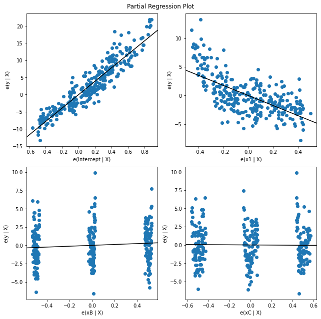

**Se observa que la varibale x1 podría tener un mejor ajuste con alguna transformación.**

### Normalidad

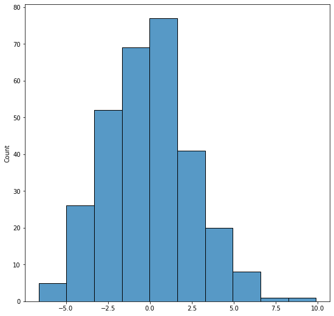

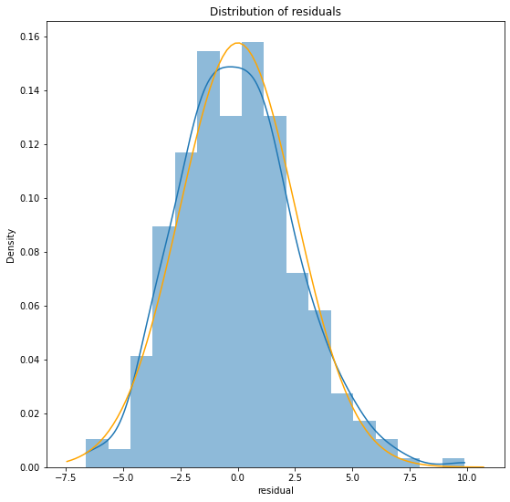

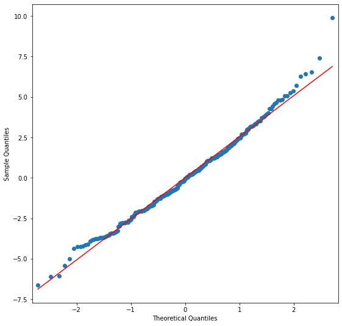

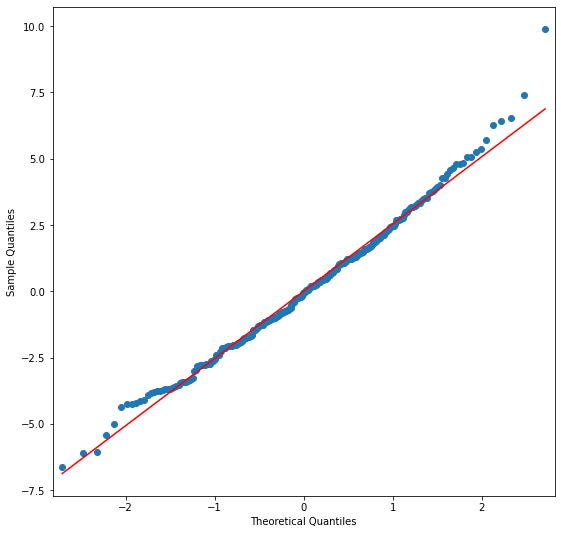

Los test Shapiro-Wilk test y D'Agostino's K-squared test son dos de los test de hipótesis más empleados para analizar la normalidad. En ambos, se considera como hipótesis nula que los datos proceden de una distribución normal.

El p-value de estos test indica la probabilidad de obtener unos datos como los observados si realmente procediesen de una población con una distribución normal con la misma media y desviación que estos. Por lo tanto, si el p-value es menor que un determinado valor (típicamente 0.05), entonces se considera que hay evidencias suficientes para rechazar la normalidad.

```
Preuba de Shapiro-Wilk: Estadístico = 0.99077969789505, p-value = 0.056499727070331573
```

```
Prueba de D'Agostino: Estadístico = 9.08705473907287, p-value = 0.010635823827445635
```

Dado que las pruebas anteriores no son concluyentes, realizaré un par de pruebas adicionales usando el método de Kolmogorov-Smirnov y Jarque-Bera. En estas pruebas también ocurre que si el p-value es menor que un determinado valor (típicamente 0.05), entonces se considera que hay evidencias suficientes para rechazar la normalidad.

```python
# Kolmogorov-Smirnov
# ==============================================================================
k3, p_value2 = stats.kstest(model_r.resid, "norm")
print(f"Prueba de Kolmogorov-Smirnov: Estadístico = {k3}, p-value = {p_value2}")
```

```
Prueba de Kolmogorov-Smirnov: Estadístico = 0.23417504753318247, p-value = 5.944129106369639e-15
```

```python
# Jarque-Bera
# ==============================================================================
k4, p_value4 = stats.jarque_bera(model_r.resid)
print(f"Prueba de Jarque-Bera: Estadístico = {k4}, p-value = {p_value4}")
```

```
Prueba de Jarque-Bera: Estadístico = 9.180483715534129, p-value = 0.01015040312263693
```

**Por lo tanto, se rechaza el supuesto de normalidad para los residuales.**

### Homocedasticidad

La suposición de homoscedasticidad es una suposición vital. Si esta suposición es violada, entonces los errores estándar serán sesgados. Los errores estándar se utilizan para realizar pruebas de significación y calcular los intervalos de confianza.

Esto puede ser probado usando un residual vs. valores ajustados, mirando un gráfico de dispersión (si una forma de como está presente entonces heteroscedasticidad está presente), o mediante el uso de una prueba estadística como Bruesch-Pagan, prueba de Cook-Weisberg, o prueba general blanca. En este ejemplo, se utilizará la prueba Bruesch-Pagan, la cuál tienen como hipótesis nula que hay presencia de homocedasticidad.

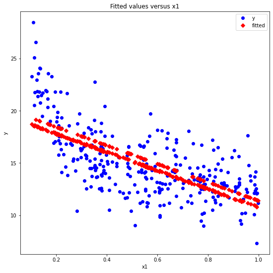

```
Resultados de la prueba de Breusch-Pagan:
  Multiplicador de Lagrange: 21.397885686640052
  p-value: 0.0006811620837045112
  f-value: 4.516102404590047
  f p-value: 0.0005553472323675712
```

**Por lo tanto, se rechaza que los residuales se distribuyen con varianza similar**